# Intro to Python (INT-2240)

### **Slide 16: Principal Component Analysis (PCA) for Dimensionality Reduction**

- **Concept**: PCA is a technique used to reduce the dimensionality of a dataset by transforming it into a smaller set of uncorrelated variables (principal components) that retain most of the original variance.
- **Example**: Apply PCA to reduce a high-dimensional dataset to 2D.

```python
from sklearn.decomposition import PCA
pca = PCA(n_components=2)
X_pca = pca.fit_transform(X)

plt.scatter(X_pca[:, 0], X_pca[:, 1], c=labels, cmap='viridis')
plt.title('PCA - Dimensionality Reduction')
plt.show()
```

[output not shown]

- **Exercise**: Apply PCA to the Iris dataset and visualize the result.
- **Solution**:

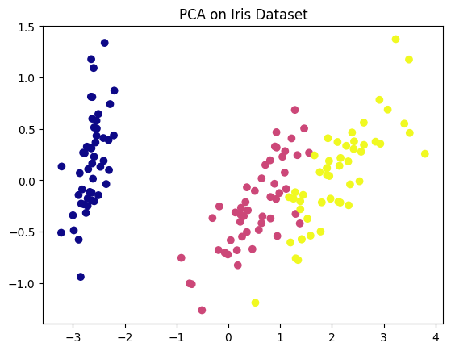

```python
from sklearn.datasets import load_iris
iris = load_iris()
X_iris = iris.data
pca_iris = PCA(n_components=2)
X_pca_iris = pca_iris.fit_transform(X_iris)
plt.scatter(X_pca_iris[:, 0], X_pca_iris[:, 1], c=iris.target, cmap='plasma')
plt.title('PCA on Iris Dataset')
plt.show()
```

### **Slide 17: Support Vector Machines (SVM) for Classification**

- **Concept**: SVM is a supervised learning algorithm used for classification by finding the hyperplane that best separates classes in the feature space.
- **Example**: Apply an SVM classifier to a dataset.

```python
from sklearn.svm import SVC
model = SVC(kernel='linear')
model.fit(X_train, y_train)
predictions = model.predict(X_test)
```

```python
from sklearn.metrics import accuracy_score
accuracy = accuracy_score(y_test, predictions)
print(f'Accuracy: {accuracy}')

  # Visualize decision boundary
plt.scatter(X_train[:, 0], X_train[:, 1], c=y_train, cmap='coolwarm')
plt.title('SVM Decision Boundary')
plt.show()
```

### hyperparameter and parameter with regard to machine learning

### the difference and similarity of these two terms; provide example to explain these two terms

### on which we can have direct control

```python
x = {1, 3, 7, 11, 13}
y = {3, 7, 15, 23, 27}
x and y are linearly related (form equation of a line)

algorithm_to_determine_equation_of_a_line(x,y)
y = mx + b # m is the slope; b is the intercept
y = 2x + 1 # m and b are parameters
x = 200
y = 2(200) + 1 = 401
```

### **Slide 18: Hyperparameter Tuning Using GridSearchCV**

- **Concept**: GridSearchCV is a method for performing exhaustive search over specified hyperparameter values of a model to find the optimal settings.
- **Example**: Use GridSearchCV to optimize the hyperparameters of an SVM.

```python
from sklearn.model_selection import GridSearchCV
param_grid = {'C': [0.1, 1, 10], 'kernel': ['linear', 'rbf']}
grid = GridSearchCV(SVC(), param_grid, refit=True)
grid.fit(X_train, y_train)
print(grid.best_params_)
```

- **Exercise**: Tune the hyperparameters of a Decision Tree using GridSearchCV.
- **Solution**:

```python
param_grid = {'max_depth': [3, 5, 10], 'min_samples_split': [2, 5, 10]}
grid = GridSearchCV(DecisionTreeClassifier(), param_grid, refit=True)
grid.fit(X_train, y_train)
print(grid.best_params_)
```

### **Slide 19: K-Nearest Neighbors (KNN) for Classification**

- **Concept**: KNN is a simple, non-parametric algorithm that classifies data points based on the classes of their nearest neighbors.
- **Example**: Train and evaluate a KNN classifier.

```python
from sklearn.neighbors import KNeighborsClassifier
model = KNeighborsClassifier(n_neighbors=5)
model.fit(X_train, y_train)
predictions = model.predict(X_test)
```

- **Exercise**: Plot the decision boundary of a KNN classifier and evaluate its accuracy.
- **Solution**:

```python
from sklearn.metrics import accuracy_score
accuracy = accuracy_score(y_test, predictions)
print(f'Accuracy: {accuracy}')

# Visualization of the KNN decision boundary would require meshgrid plotting.
```

### **Slide 20: Naive Bayes for Text Classification**

- **Concept**: Naive Bayes classifiers are probabilistic models that are particularly useful for text classification tasks such as spam detection.
- **Example**: Train a Naive Bayes classifier on a text dataset.

```python
from sklearn.naive_bayes import MultinomialNB
from sklearn.feature_extraction.text import CountVectorizer

vectorizer = CountVectorizer()
X_train_vect = vectorizer.fit_transform(X_train)

model = MultinomialNB()
model.fit(X_train_vect, y_train)
predictions = model.predict(vectorizer.transform(X_test))
```

- **Exercise**: Evaluate the performance of the Naive Bayes classifier using a confusion matrix.
- **Solution**:

```python
from sklearn.metrics import confusion_matrix
cm = confusion_matrix(y_test, predictions)
print(cm)
```

### **Slide 21: RandomizedSearchCV for Efficient Hyperparameter Tuning**

- **Concept**: RandomizedSearchCV is a method that samples a given number of parameter settings from specified distributions and evaluates them, providing a more efficient alternative to GridSearchCV.
- **Example**: Use RandomizedSearchCV to tune the hyperparameters of a Random Forest.

```python
from sklearn.model_selection import RandomizedSearchCV
param_distributions = {'n_estimators': [100, 200, 300], 'max_depth': [5, 10, 20]}
random_search = RandomizedSearchCV(RandomForestClassifier(), param_distributions, n_iter=10)
random_search.fit(X_train, y_train)
print(random_search.best_params_)
```

- **Exercise**: Tune hyperparameters of an SVM using RandomizedSearchCV.
- **Solution**:

```python
param_distributions = {'C': [0.1, 1, 10], 'kernel': ['linear', 'poly', 'rbf']}
random_search = RandomizedSearchCV(SVC(), param_distributions, n_iter=10)
random_search.fit(X_train, y_train)
print(random_search.best_params_)
```

### **Slide 22: Gradient Boosting for Classification and Regression**

- **Concept**: Gradient Boosting is an ensemble technique that builds models sequentially, each new model correcting the errors of the previous one.
- **Example**: Apply Gradient Boosting for classification.

```python
from sklearn.ensemble import GradientBoostingClassifier
model = GradientBoostingClassifier(n_estimators=100, learning_rate=0.1)
model.fit(X_train, y_train)
predictions = model.predict(X_test)
```

```python
from sklearn.metrics import roc_curve, auc
fpr, tpr, thresholds = roc_curve(y_test, model.predict_proba(X_test)[:,1])
roc_auc = auc(fpr, tpr)
plt.plot(fpr, tpr, label=f'ROC curve (area = {roc_auc:.2f})')
plt.show()
```

### **Slide 23: Introduction to Neural Networks with Keras**

- **Concept**: Neural networks are a set of algorithms modeled after the human brain, designed to recognize patterns in data. They are especially powerful for image recognition, natural language processing, and other complex tasks.
- **Example**: Build a simple feed-forward neural network using Keras.

```python
from keras.models import Sequential
from keras.layers import Dense

model = Sequential()
model.add(Dense(64, input_dim=X_train.shape[1], activation='relu'))  # Hidden Layer 1
model.add(Dense(32, activation='relu'))  # Hidden Layer 2
model.add(Dense(1, activation='sigmoid'))  # Output Layer for binary classification

model.compile(loss='binary_crossentropy', optimizer='adam', metrics=['accuracy'])
model.fit(X_train, y_train, epochs=10, batch_size=32, validation_split=0.2)
```

- **Exercise**: Build a neural network using Keras for multiclass classification.
- **Solution**:

```python
model = Sequential()
model.add(Dense(128, input_dim=X_train.shape[1], activation='relu'))  # Hidden Layer 1
model.add(Dense(64, activation='relu'))  # Hidden Layer 2
model.add(Dense(10, activation='softmax'))  # Output Layer for 10 classes

model.compile(loss='categorical_crossentropy', optimizer='adam', metrics=['accuracy'])
model.fit(X_train, y_train, epochs=20, batch_size=64, validation_split=0.2)
```

### **Slide 24: Convolutional Neural Networks (CNN) for Image Classification**

- **Concept**: CNNs are deep learning models specifically designed for working with grid-like data, such as images. CNNs utilize convolutional layers that automatically learn spatial hierarchies.
- **Example**: Build a CNN using Keras for image classification (e.g., MNIST digits dataset).

```python
  from keras.datasets import mnist
  from keras.utils import to_categorical
  from keras.models import Sequential
  from keras.layers import Conv2D, MaxPooling2D, Flatten, Dense

  (X_train, y_train), (X_test, y_test) = mnist.load_data()
  X_train = X_train.reshape(X_train.shape[0], 28, 28, 1).astype('float32') / 255
  X_test = X_test.reshape(X_test.shape[0], 28, 28, 1).astype('float32') / 255
  y_train = to_categorical(y_train)
  y_test = to_categorical(y_test)

  model = Sequential()
  model.add(Conv2D(32, kernel_size=(3, 3), activation='relu', input_shape=(28, 28, 1)))
  model.add(MaxPooling2D(pool_size=(2, 2)))
  model.add(Conv2D(64, kernel_size=(3, 3), activation='relu'))
  model.add(MaxPooling2D(pool_size=(2, 2)))
  model.add(Flatten())
  model.add(Dense(128, activation='relu'))
  model.add(Dense(10, activation='softmax'))

  model.compile(loss='categorical_crossentropy', optimizer='adam', metrics=['accuracy'])
  model.fit(X_train, y_train, epochs=10, batch_size=128, validation_split=0.2)
```

- **Exercise**: Train a CNN model on the CIFAR-10 dataset for image classification.
- **Solution**:

```python
  from keras.datasets import cifar10
  (X_train, y_train), (X_test, y_test) = cifar10.load_data()
  X_train = X_train.astype('float32') / 255
  X_test = X_test.astype('float32') / 255
  y_train = to_categorical(y_train)
  y_test = to_categorical(y_test)

  # Add layers similar to the MNIST example but adjust for the RGB images in CIFAR-10
```